# practicalMachineLearning

Martin Sawtell

Thursday, January 28, 2016

# Overview

This report outlines the process of predicting the manner in which subjects performed physical tests, as measured by various accelerometers. The variable to predict is called CLASSE.

Training dataset: https://d396qusza40orc.cloudfront.net/predmachlearn/pml-training.csv

Test dataset: https://d396qusza40orc.cloudfront.net/predmachlearn/pml-testing.csv

# Set up environment

First load the required libraries and set the seed (assuming the end user has those libraries installed):

```r
library(knitr)
library(RCurl)
library(corrplot)
library(caret)
library(randomForest)
```

# Load data

Read in the datasets:

```r
trainURL <- "https://d396qusza40orc.cloudfront.net/predmachlearn/pml-training.csv"
testURL <- "https://d396qusza40orc.cloudfront.net/predmachlearn/pml-testing.csv"

tra <- getURL(trainURL)
tst <- getURL(testURL)

trainingRaw <- read.csv(textConnection(tra))
testRaw <- read.csv(textConnection(tst))

dim(trainingRaw)
```

```
## [1] 19622   160
```

```r
dim(testRaw)
```

```
## [1]  20 160
```

# Data Cleaning and prep

Clean data by removing the ID tags, Near Zero Variance values and useless NA variables:

```r
#nuke the id tags and make a cleaned data object:
trainingCl <- trainingRaw[, -(1:5)]
testCl  <- testRaw[, -(1:5)]

#NZV:
zeroMask <- nearZeroVar(trainingCl)
trainingCl <- trainingCl[, -zeroMask]
testCl  <- testCl[, -zeroMask]

length(names(trainingRaw))
```

```
## [1] 160
```

```r
length(names(trainingCl))
```

```
## [1] 95
```

```r
#next clean the mainly NA values out:
AllNA    <- sapply(trainingCl, function(x) mean(!is.na(x))) < 0.95
trainingCl <- trainingCl[, AllNA==FALSE]
testCl  <- testCl[, AllNA==FALSE]

length(names(trainingCl))
```

```
## [1] 54
```

Now split the trainingCl dataset into the training and validation partitions, using a reproducable seed:

```r
set.seed(934857)
inTrain <- createDataPartition(trainingCl$classe, p=0.75, list=F)
trainSet <- trainingCl[inTrain, ]
testSet <- trainingCl[-inTrain, ]
```

# Data Exploration:

Correlation Analysis:

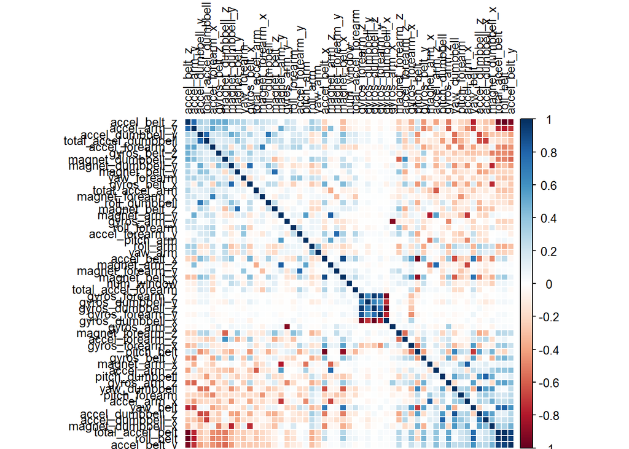

```r
corrMatrix <- cor(trainSet[, -54])
corrplot(corrMatrix, order = "FPC", method = "color",
         tl.cex = 0.8, tl.col = rgb(0, 0, 0))
```

# Random Forest

```r
control <- trainControl(method="cv", 3)
model <- train(classe ~ ., data=trainSet, method="rf", trControl=control)
model
```

```
## Random Forest
##
## 14718 samples
##    53 predictor
##     5 classes: 'A', 'B', 'C', 'D', 'E'
##
## No pre-processing
## Resampling: Cross-Validated (3 fold)
## Summary of sample sizes: 9812, 9812, 9812
## Resampling results across tuning parameters:
##
##   mtry  Accuracy   Kappa      Accuracy SD   Kappa SD
##    2    0.9923903  0.9903736  0.0018939204  0.0023955469
##   27    0.9959234  0.9948432  0.0005392889  0.0006823093
##   53    0.9933415  0.9915771  0.0011590381  0.0014663255
##
## Accuracy was used to select the optimal model using  the largest value.
## The final value used for the model was mtry = 27.
```

# Error Estimate & Cross Validation

```r
predict <- predict(model, testSet)
confusionMatrix(testSet$classe, predict)
```

```
## Confusion Matrix and Statistics
##
##           Reference
## Prediction    A    B    C    D    E
##          A 1395    0    0    0    0
##          B    0  948    1    0    0
##          C    0    3  852    0    0
##          D    0    0    1  803    0
##          E    0    0    0    1  900
##
## Overall Statistics
##
##                Accuracy : 0.9988
##                  95% CI : (0.9973, 0.9996)
##     No Information Rate : 0.2845
##     P-Value [Acc > NIR] : < 2.2e-16
##
##                   Kappa : 0.9985
##  Mcnemar's Test P-Value : NA
##
## Statistics by Class:
##
##                      Class: A Class: B Class: C Class: D Class: E
## Sensitivity            1.0000   0.9968   0.9977   0.9988   1.0000
## Specificity            1.0000   0.9997   0.9993   0.9998   0.9998
## Pos Pred Value         1.0000   0.9989   0.9965   0.9988   0.9989
## Neg Pred Value         1.0000   0.9992   0.9995   0.9998   1.0000
## Prevalence             0.2845   0.1939   0.1741   0.1639   0.1835
## Detection Rate         0.2845   0.1933   0.1737   0.1637   0.1835
## Detection Prevalence   0.2845   0.1935   0.1743   0.1639   0.1837
## Balanced Accuracy      1.0000   0.9983   0.9985   0.9993   0.9999
```

```r
#Overall accuracy estimate:
confusionMatrix(testSet$classe, predict)$overall
```

```
##       Accuracy          Kappa  AccuracyLower  AccuracyUpper   AccuracyNull
##      0.9987765      0.9984524      0.9973389      0.9995509      0.2844617
## AccuracyPValue  McnemarPValue
##      0.0000000            NaN
```

```r
#Estimated out of sample error:
1-as.numeric(confusionMatrix(testSet$classe, predict)$overall[1])
```

```
## [1] 0.001223491
```

As you can see, the estimated out of sample error rate on the test subset is extremely low. We will move forward with this model.

# Final model validation

Applying the model to the final test dataset:

```r
predict(model, newdata=testCl)
```

```
##  [1] B A B A A E D B A A B C B A E E A B B B
## Levels: A B C D E
```